# Understanding the S.O.E. Expereince

# Understanding the Gendered S.O.E. Experience

**NOTE: Content featured may be difficult for some audiences to consume, including discussions of death, murder, suicide, and violence. Viewer discretion is advised.</b>**

The Special Operations Executive, or the S.O.E., was a civilian branch of the British Army during the Second World War tasked with espionage behind enemy lines in both the Asian and European spheres of war. These agents ranged from housewives to hardened soldiers, whose varied identities create a unique area of analysis for gender history, and how masculinity and femininity separately affected these agents in recruitment, deployment, capture, execution, and survival. However, between limited access to agents files, and the secretive nature of much of their word, these agents have evaded historical and intersectional analysis.

This project, Understanding the Gendered S.O.E. Experience, divided into life, death, and legacy, is a first attempt at understanding the impact of gender on these agent’s experiences in the field using digital methods, turning python programming into a powerful tool in revealing the hidden histories behind agents deaths.

# Dead Agents

To first understand the impact of gender on agents who died during the war is to first choose a set of agents to analyze. Seeing as there were thousands of agents deployed, this can be quite the challenge.

Let's begin with female agents.

Female agents were far less likely to be deployed than male, with only 45 deployed, though this number is up to the researcher's discretion of whom they choose to consider an agent. My personal criteria for a female S.O.E. agent was that they had to have some form of personnel record with the British National Archives. For example, there were many women who aided the resistance, but only those actually recruited and deployed would have actual personnel records.

Of these, 14 died during the war, because of their involvement. In the case of Madeline Lavigne and Muriel Byck, included in the 'Alive Agents' code, they died from natural causes, and as such, their deaths cannot be contributed to their work in the field.

From here, it was far more difficult to pick male agents. After all, there is no way to analyze all male agents within the given scope and timeframe of this project, but just choosing a random handful also does not tell the whole picture.

As such, I've chosen 14 male agents who were deployed at the **SAME TIME** as female agents. For some male agents, this means they were deployed together with female agents and worked in the field with them, while for others, they were deployed on the same day, or within a close time frame. This way, we can understand gendered experiences by studying agents who, if deployed at the same time with the same conditions, should have similar experiences. The gendered differences of those experiences and their deaths, then, can be analyzed.

There are, of course, certain issues with this. In some cases, agents deployed alongside female agents survived, and cannot be used to study deaths. One notable inclusion in this is the fate of Charles Skepper, who, like many soldiers, was considered Missing in Action, and likely sent to a concentration camp, where he likely would have died. Unfortunately, there is no record, as S.O.E. agents were not considered soldiers and treated the same, and many stuck to undercover identities when put into concentration camps, making it even more difficult to track them. As well, in the case of Haviva Reik and Madeline Barclay, their unique areas of death meant it was difficult to find male agents deployed in the same location, and with Vera Leigh, all men deployed around her survive. As such, I have chosen three random men, deployed in other areas outside (The Netherlands, France and Denmark), who were deployed on the same day, or in the case of Barclay, are assumed to have been deployed on similar days. As such, there has been my authorial discretion in using certain agents over others.

What I hope that by having 14 female agents, and 14 male agents deployed at the same time as them, I can show a fraction of how gender impacted spies in the field through direct correlations. This project is by no means the WHOLE picture, nor do I claim that my correlations count for ALL agents. As well, it is important to know that the overage percentages are heavily skewed by the equal split between male and female agents, for if this included all agents, the ratio would see far more men holding far more sway over female agents percentages. This is something I will discuss within the graphs as needed.

# CSV Breakdown

To then begin with the code, here is the CSV I created that contained what I believed to be relevant information to the agents in the field:

Their name, and for women, typically their maiden name. This is due to the fact that many married after the war, meaning the names included on documents used would be their maiden name.

Country of Deployment and Location of Deployment allow for understandings of total numbers of agents, and the exact locations of thei deployment.

Location of Death is the location in which an agent was killed. It is worth noting that location names have changed since the war. Bas-Rhin, France, was Natzweiler-Struthof, a concentration camp. Other concentration camps are Bergen-Belson, Buchenwald, Ravensbruck, Flossenburg, and Dachau. Other locations are where agents died in the field, besides Charles Skepper, who simply is given the death location of 'Germany'. This is because the last known traces of him are that he was sent to Germany, but no records survive beyond that.

Year of Deployment, while fairly straightforward, also contains nuance. Certain agents worked for the French resistance before being recruited by the S.O.E. Year of deployment, then, is when agents are redeployed into a country after receiving S.O.E. training, either in the UK, or within their country of deployment.

Total Months in the Field, Excluding Capture, is how long agents spent into the field, whether it was just one trip, or tallied if multiple.

Date of Death is the year in while an agent was killed. For many agents killed in concentration camps, the exact date of their death is unknown, however, the year is. The only outlier present is Madeline Barclay, who drowned in 1943; all other deaths fall in 1944 and 1945, either with the ramping up of efforts to surpress rebellion in France, or the need to liquidate camps across Europe with the war drawing to a close.

Cause of Death includes categories of death. Concentration Camp Execution is being killed in a concentration camp, while concentration camp succumbed to sickness was dying due to the conditions of the concentration camp. KIA, or Killed in Action, means that while engaging in some form of attack, sabotage, battle, etc., an agent was killed outright. One agent, Hans Robert Filip Johansen, I have chosen to label Killed in Action, though some may disagree with this categorization. Cornered, Johansen took a cyanide pill that many S.O.E. agents carried with them to save them from torture and more brutal deaths.**1** While this may be considered suicide, I still consider this being Killed in Action, as he died while fighting in the field. Drowned, a unique death for Madeline Barclay, is that her submarine was targetted and sank. Unknown, as mentioned above, is for Charles Skepper who is believed to have died in a concentration camp, but there is no actual cause of death. Execution is that, once captured, an agent was killed in the field, and succumbed to injuries is for agents who were injured in the field, and later died because of this.

As well, it is worth noting the unique sequence of agents: the female-male back and forth of each row signifies that each pair of agents were deployed at or around the same time, starting with Andree Borrel and Brian Dominic Rafferty, then Cecily Lefort and Charles Skepper, so on, and so forth.

With all that said, lets get into these agents.

```python
import pandas
import folium
import geopy

from geopy.geocoders import Nominatim

geolocator = Nominatim(user_agent="Grace_War_Death", timeout=2)

Died = pandas.read_csv('UpdatedDeathCSV11.csv', delimiter=",")
pandas.options.display.max_rows = 999

Died.drop('Pairing', axis=1)
```

|  | Name | Country of Deployment | Location of Deployment | Location of Death | Country of Origin | Gender | Date of Birth | Date of Deployment | Months in the Field | Job | Date of Death | Cause of Death |
| --- | --- | --- | --- | --- | --- | --- | --- | --- | --- | --- | --- | --- |
| 0 | Andrée Borrel | France | Bois Renard, 41210 Saint-Viâtre, France | Bas-Rhin, France | France | Female | 1919 | 1942 | 9 | Courier | 1944 | Concentration Camp Execution |
| 1 | Brian Dominic Rafferty | France | Plauzat, France | Flossenbürg, Germany | England | Male | 1919 | 1942 | 9 | Organiser | 1945 | Concentration Camp Execution |
| 2 | Cecily Lefort | France | Briollay, France | Ravensbrück, Germany | England | Female | 1899 | 1943 | 3 | Courier | 1945 | Concentration Camp Execution |
| 3 | Charles Skepper | France | Briollay, France | Germany | England | Male | 1905 | 1943 | 9 | Organiser | 1944 | Unknown |
| 4 | Denise Bloch | France | Armonville, 28310 Toury, France | Ravensbrück, Germany | France | Female | 1916 | 1944 | 3 | Courier | 1945 | Concentration Camp Execution |
| 5 | John Dennis Barrett | France | Seine & Marne, France | Buchenwald, Weimar, Germany | England | Male | 1916 | 1944 | 4 | Wireless Operator | 1944 | Concentration Camp Execution |
| 6 | Diana Rowden | France | Briollay, France | Bas-Rhin, France | England | Female | 1915 | 1943 | 5 | Courier | 1944 | Concentration Camp Execution |
| 7 | Ken McAlister | France | Meusnes, France | Flossenbürg, Germany | Canada | Male | 1914 | 1943 | 1 | Wireless Operator | 1944 | Concentration Camp Execution |
| 8 | Eliane Sophie Plewman | France | Lothiers, France | Dachau | France | Female | 1917 | 1943 | 7 | Courier | 1944 | Concentration Camp Execution |
| 9 | Eric Joseph Denis Cauchi | France | Blye, France | Montbéliard, France | Greece | Male | 1911 | 1943 | 6 | Weapons Instructor | 1944 | KIA |
| 10 | Haviva Reik | Slovakia | Banská Bystrica, Slovakia | Kremnička, Slovakia | Slovakia | Female | 1922 | 1944 | 2 | Field Agent | 1945 | KIA |
| 11 | Willem Frederik Hoogewerff, | Netherlands | Berkel, Netherlands | 2244 AJ Wassenaar, Netherlands | Netherlands | Male | 1921 | 1944 | 5 | Weapons Instructor | 1945 | Executed |
| 12 | Lilian Rolfe | France | Azay sur Cher, France | Ravensbrück, Germany | France | Female | 1914 | 1944 | 3 | Wireless Operator | 1945 | Concentration Camp Execution |
| 13 | Stanislaw Makowski | France | Nuret le Ferron, France | Romorantin-Lanthenay, France | Poland | Male | 1914 | 1944 | 4 | Second in Command | 1944 | Succumbed to Injury |
| 14 | Madeleine Barclay | North Atlantic Ocean | North Atlantic Ocean | Azores | France | Female | 1911 | 1942 | 3 | Wireless Operator | 1943 | Drowned |
| 15 | Gustave Biéler | France | Gondreville, France | Buchenwald, Weimar, Germany | France | Male | 1904 | 1942 | 14 | Organiser | 1944 | Concentration Camp Execution |
| 16 | Madeleine Damerment | France | Sainville, France | Dachau | France | Female | 1917 | 1944 | 0 | Courier | 1944 | Concentration Camp Execution |
| 17 | Julien Detal | France | Daon, France | Buchenwald, Weimar, Germany | England | Male | 1915 | 1944 | 0 | Organiser | 1944 | Concentration Camp Execution |
| 18 | Noor Inayat Khan | France | Briollay, France | Dachau | Russia | Female | 1914 | 1943 | 2 | Wireless Operator | 1944 | Concentration Camp Execution |
| 19 | Arthur Steele | France | Souvigny, France | Buchenwald, Weimar, Germany | France | Male | 1921 | 1943 | 9 | Wireless Operator | 1944 | Concentration Camp Execution |
| 20 | Vera Leigh | France | Le Port, 37510 Villandry, France | Bas-Rhin, France | England | Female | 1903 | 1943 | 5 | Courier | 1944 | Concentration Camp Execution |
| 21 | Hans Robert Filip Johansen | Denmark | Hvidsten, Denmark | Nyhavn, Copenhagen, Denmark | Denmark | Male | 1921 | 1943 | 14 | Sabotage Instructor | 1944 | KIA |
| 22 | Violette Szabo | France | Azay sur Cher, France | Ravensbrück, Germany | France | Female | 1921 | 1944 | 1 | Courier | 1945 | Concentration Camp Execution |
| 23 | Marcel Leccia | France | Néret, France | Buchenwald, Weimar, Germany | France | Male | 1911 | 1944 | 2 | Organiser | 1944 | Concentration Camp Execution |
| 24 | Yolande Beekman | France | Villevêque\n49140 Rives-du-Loir-en-Anjou\nFrance | Dachau | France | Female | 1911 | 1943 | 4 | Wireless Operator | 1944 | Concentration Camp Execution |
| 25 | Robert Lefranc | France | Villemade, France | Dracy Saint-Loup, France | France | Male | 1921 | 1943 | 12 | Wireless Operator | 1944 | KIA |
| 26 | Yvonne Rudelatt | France | Cap d'Antibes, France | Bergen-Belsen, Germany | France | Female | 1897 | 1942 | 11 | Courier | 1945 | Concentration Camp Succumbed to Sickness |
| 27 | Henri Jacques Frager | France | Cap d'Antibes, France | Buchenwald, Weimar, Germany | France | Male | 1897 | 1942 | 20 | Organiser | 1945 | Concentration Camp Execution |

Now, knowing that agents come in pairs based on deployment, how close was that deployment?

```python
DeployToget = pandas.read_csv('DeathTiming5.csv', delimiter=",")
pandas.options.display.max_rows = 999

DeployToget
```

|  | Female Agent | Male Agent | Deployment Timing | Location | Female Job | Male Job |
| --- | --- | --- | --- | --- | --- | --- |
| 0 | Andrée Borrel | Brian Dominic Rafferty | 1 Day Apart | France | Courier | Organiser |
| 1 | Cecily Lefort | Charles Skepper | Same Day, Same Mission | France | Courier | Organiser |
| 2 | Denise Bloch | John Dennis Barrett | 1 Day Apart | France | Courier | Wireless Operator |
| 3 | Diana Rowden | Ken McAlister | 1 Day Apart | France | Courier | Wireless Operator |
| 4 | Eliane Sophie Plewman | Eric Joseph Denis Cauchi | Same Day, Different Mission | France | Courier | Weapons Instructor |
| 5 | Haviva Reik | Willem Frederik Hoogewerff, | Same Day, Different Location | Slovakia and The Netherlands | Field Agent | Weapons Instructor |
| 6 | Lilian Rolfe | Stanislaw Makowski | Same Day, Different Mission | France | Wireless Operator | Second in Command |
| 7 | Madeleine Barclay | Gustave Biéler | Same Month, Different Mission* | Azores and France | Wireless Operator | Organiser |
| 8 | Madeleine Damerment | Julien Detal | Same Day, Different Mission | France | Courier | Organiser |
| 9 | Noor Inayat Khan | Arthur Steele | 3 Days Apart | France | Wireless Operator | Wireless Operator |
| 10 | Vera Leigh | Hans Robert Filip Johansen | Same Day, Different Location | France and Denmark | Courier | Sabotage Instructor |
| 11 | Violette Szabo | Marcel Leccia | Same Day, Different Mission | France | Courier | Organiser |
| 12 | Yolande Beekman | Robert Lefranc | 3 Days Apart | France | Wireless Operator | Wireless Operator |
| 13 | Yvonne Rudelatt | Henri Jacques Frager | Same Day, Same Mission | France | Courier | Organiser |

For a brief explanation of the Deployment Timing, *Same Day, Same Mission* means agents were deployed in the exact same locations at the same time, while *Same Day, Different Missions* means agents were deployed the same day, but were deployed in different missions. Same Day, Different Location is special for both Leigh and Johansen, and Reik and Hoogewerff, as mentioned above, it was difficult to find an agent deployed alongside Reik in Slovakia, and that there were no agents who died near Leigh, so I chose to partner them with agents from other countries, just to show how deaths in different countries looked.

_

Here, there are a couple important things to note.

For location, 12 female agents were deployed in France, with 1 agent being deployed in Slovakia and the Azores respectively. So far in my research, these are all the female agents deployed that are publically available. Emphasis must be put on the word agent for this distinction, as many women aided the S.O.E., but few were actively recruited, joined the organization, and sent in the field. It ought to be noted that S.O.E. agents worked across numerous countries, but the limitations of the deployment locations of female agents has in turn limited the amount of areas included in my own analysis.

While women collaborated with the S.O.E. in countless countries, actual female S.O.E. agents were deeply limited to where they could be deployed, with only two of the women who were killed being deployed outside of France.

Why? Well, first because France was the main target of the S.O.E., but as well that many people, female and male, had education in French, meaning they could pass within France. As for gender specific reasons, women were mainly deployed to France as they were less likely to raise suspicion. As mentioned above, there were few men in France, as they were supposed to either be Prisoners of War or working as labour for the Germans, leaving only the physically unfit for labour and the elderly in France. Women, however, were not included in these labour round-ups, meaning that female agents would raise much less suspicion being out-and-about in France.

What about the women, then, deployed outside of France?

Madeline Barclay was aboard a submarine that was supposed to aid Vichy France, but the ship was ultimately chosen to go instead to Asia, and was downed by a U-Boat near the Azores.**2** Haviva Reik was a Jewish parachutist that underwent S.O.E. training before being deployed into her home country of Slovakia, where she was killed in action.**3** Both women are unique in their recruitment, position, and as such, are unique in their deaths.

## Agents Deployment

Now, having seen where agents shared deployed countries, what about exact locations? This map shows where agents were deployed, with green parachutes signifying male agents, and red signifying female.

**NOTE: You will have to zoom in on certain locations to be able to see all those deployed.**

```python
Death_map = folium.Map(location=[46.2276, 2.2137], zoom_start=3)

import time

icon_url = 'https://cdn-icons-png.flaticon.com/512/4533/4533299.png'
icon_url2 = 'https://cdn-icons-png.flaticon.com/512/238/238569.png'

increase = 0

for index, row in Died.iterrows():

        time.sleep(1)
        location = geolocator.geocode(row['Location of Deployment'])

        year = row['Date of Deployment']
        name = row['Name']
        Descript = "Agent:", name, "Date of Deployment:", year

        increase +=0.00005
        Final_Lat = (location.latitude + increase)
        Final_Log = (location.longitude + increase)

        if('Male' in row['Gender']):
            icon = folium.features.CustomIcon(icon_url2,icon_size=(28, 30))
        else:
            icon = folium.features.CustomIcon(icon_url,icon_size=(28, 30))

        folium.Marker(location=[Final_Lat, Final_Log],popup = Descript, icon=icon).add_to(Death_map)

Death_map
```

Make this Notebook Trusted to load map: File -> Trust Notebook

[interactive chart not shown]

## Agents Death Locations

Now, having seen where agents were deployed, what about where they died? Red markers signify female agents, and green signify male.

```python
Death_map = folium.Map(location=[46.2276, 2.2137], zoom_start=3)

import time

icon_url = 'https://cdn-icons-png.flaticon.com/512/4533/4533299.png'
icon_url2 = 'https://cdn-icons-png.flaticon.com/512/238/238569.png'

increase = 0

for index, row in Died.iterrows():

        time.sleep(1)
        location = geolocator.geocode(row['Location of Death'])

        year = row['Date of Death']
        name = row['Name']
        Descript = "Agent:", name, "Date of Death:", year

        increase +=0.00005

        Final_Lat = (location.latitude + increase)
        Final_Log = (location.longitude + increase)

        if ('Female' in row['Gender']):
            folium.Marker(location=[Final_Lat, Final_Log],popup = Descript, icon=folium.Icon(color='red',icon='remove-sign')).add_to(Death_map)
        else:
            folium.Marker(location=[Final_Lat, Final_Log],popup = Descript, icon=folium.Icon(color='darkgreen',icon='remove-sign')).add_to(Death_map)

Death_map
```

Make this Notebook Trusted to load map: File -> Trust Notebook

[interactive chart not shown]

## Death Distances

Now, we can see where agents deployed, and where they died, but what about the distances between these two? The map below features a line connecting the deployment and death locations, to get a better understanding of how far some agents travelled, and how far some were sent, before their deaths.

```python
Death_map = folium.Map(location=[46.2276, 2.2137], zoom_start=3)

import time

icon_url = 'https://cdn-icons-png.flaticon.com/512/4533/4533299.png'
icon_url2 = 'https://cdn-icons-png.flaticon.com/512/238/238569.png'

increase = 0

for index, row in Died.iterrows():


        time.sleep(1)
        location = geolocator.geocode(row['Location of Death'], language='en')


        year = row['Date of Death']
        name = row['Name']
        Descript = "Agent:", name, "Date of Death:", year

        increase +=0.00005

        Final_Lat = (location.latitude + increase)
        Final_Log = (location.longitude + increase)
        time.sleep(1)

        Origlocation = geolocator.geocode(row['Location of Deployment'], language='en')
        Orig_Lat = (Origlocation.latitude)
        Orig_Log = (Origlocation.longitude)

        coordinates = [ [Orig_Lat, Orig_Log],  [Final_Lat, Final_Log]]

        if ('Female' in row['Gender']):
            icon = folium.features.CustomIcon(icon_url,icon_size=(28, 30))
            folium.Marker(location=[Orig_Lat,Orig_Log],popup = Descript, icon=icon).add_to(Death_map)
            folium.Marker(location=[Final_Lat, Final_Log],popup = Descript, icon=folium.Icon(color='red',icon='remove-sign')).add_to(Death_map)
            my_PolyLine=folium.PolyLine(locations=coordinates,weight=3,color='red',popup=Descript)
        else:
            icon = folium.features.CustomIcon(icon_url2,icon_size=(28, 30))
            folium.Marker(location=[Orig_Lat,Orig_Log],popup = Descript, icon=icon).add_to(Death_map)
            folium.Marker(location=[Final_Lat, Final_Log],popup = Descript, icon=folium.Icon(color='darkgreen',icon='remove-sign')).add_to(Death_map)
            my_PolyLine=folium.PolyLine(locations=coordinates,weight=3,color='green',popup=Descript)

        Death_map.add_child(my_PolyLine)
        time.sleep(1)

Death_map
```

Make this Notebook Trusted to load map: File -> Trust Notebook

[interactive chart not shown]

# Map Explanations

So, what do these maps tell us?

# Overall Agent Understanding

## Total Percentage of Death by Country of Deployment

So, before we analyze each gender, what overall understanding of agents should we have?

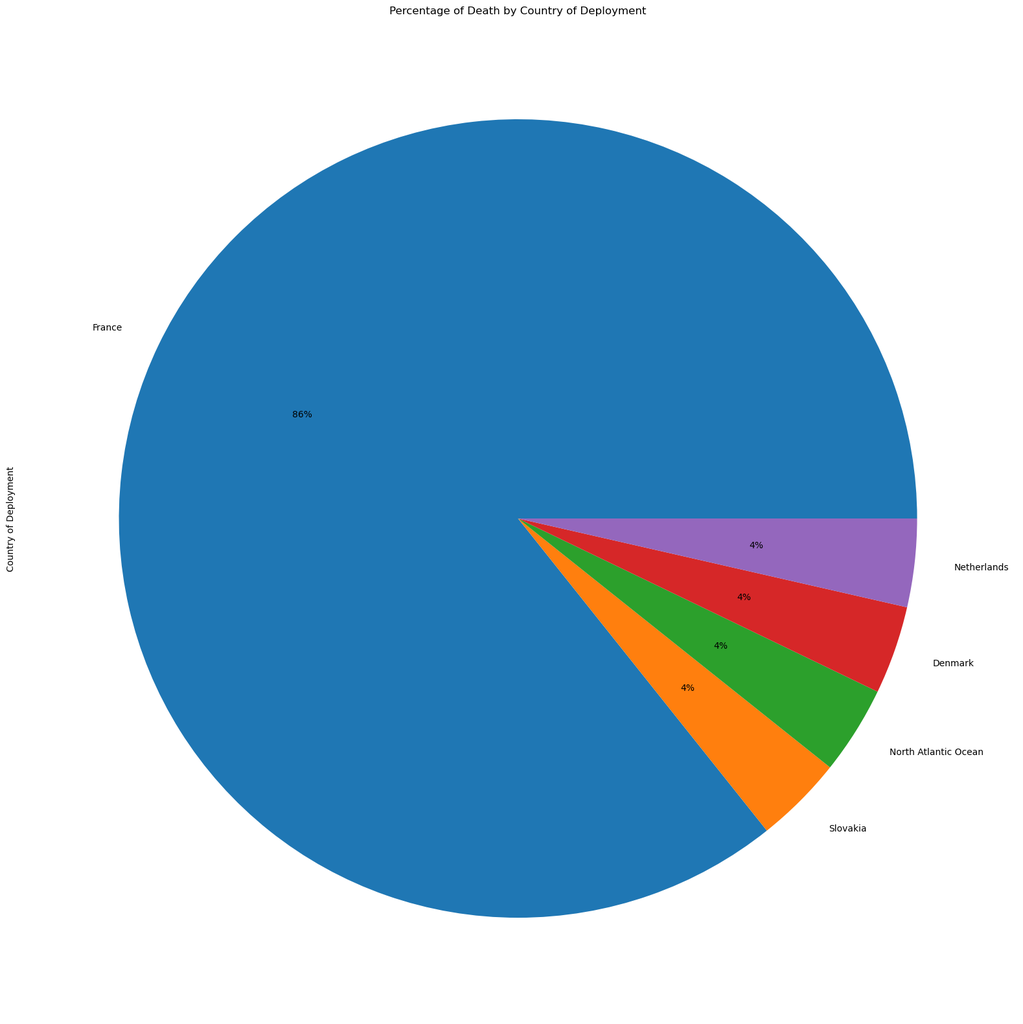

```python
Died['Country of Deployment'].value_counts().plot(kind='pie',figsize=(20,20),autopct='%1.0f%%',title='Percentage of Death by Country of Deployment')
```

Female agents were, as mentioned above, mainly restricted to being deployed in France, meaning that by choosing male agents who were deployed alongside them, it will have a French deployment bias. Both Denmark and the Netherlands have been included, as mentioned above, since there were no men who shared deployment dates with certain female agents, so agents from other countries who matche deployment dates were chosen.

In reality, S.O.E. agents were deployed in countless countries. This graph serves as a reminder moving forward to recognize that, while these numbers are important in starting to understand the correlations between gender and death, they are limited by my scope.

## Jobs

So, how did a job impact an agents ability in the field?

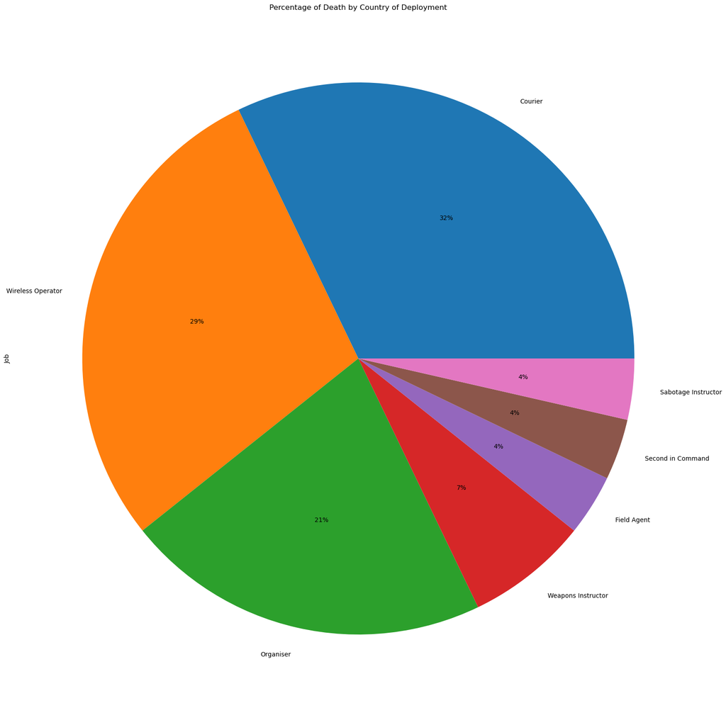

```python
Died['Job'].value_counts().plot(kind='pie',figsize=(20,20),autopct='%1.0f%%',title='Percentage of Death by Country of Deployment')
```

The largest percentage of agents in this dataset who died were couriers, which makes sense. Couriers performed various tasks, often moving around, and were the most likely to interact with Nazi officers, or to draw suspicion to themselves. Following are Wireless Operators, which some many consider confusing, as wireless operators were typically hidden and not allowed out in the field. However, wireless sets could be detected if a Wireless Operator utilized them for too long, making them easy targets to find. Following, then, are Organisers, those in charge of circuits, and then it drops off to much smaller percentage of jobs that were, in this instance, more rare occurences.

While not the whole picture, it does show the general trend of what the most dangerous jobs were comparatively, which will reveal more when broken down by gender later.

## Deployment and Death Years

What were the average years for deployment and death, and what might be the cause of this?

```
0  agents were deployed in 1941,  0  were women, and  0  were men.
6  agents were deployed in 1942,  3  were women, and  3  were men.
12  agents were deployed in 1943,  6  were women, and  6  were men.
10  agents were deployed in 1944,  5  were women, and  5  were men.
0  agents were deployed in 1945,  0  were women, and  0  were men.
```

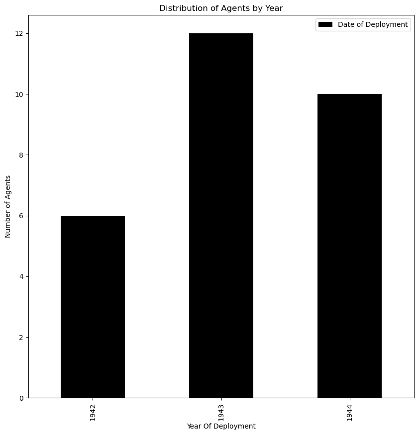

```python
counter41 = 0

counter42 = 0

counter43 = 0

counter44 = 0

counter45 = 0

femcounter41 = 0

femcounter42 = 0

femcounter43 = 0

femcounter44 = 0

femcounter45 = 0


deploycounter41 = 0

deploycounter42 = 0

deploycounter43 = 0

deploycounter44 = 0

deploycounter45 = 0

deployfemcounter41 = 0

deployfemcounter42 = 0

deployfemcounter43 = 0

deployfemcounter44 = 0

deployfemcounter45 = 0

for index, row in Died.iterrows():

    if(row['Date of Death'] == 1941):
        counter41 += 1

        if('Female' in row['Gender']):
            femcounter41 += 1

    elif(row['Date of Death'] == 1942):
        counter42 += 1

        if('Female' in row['Gender']):
            femcounter42 += 1

    elif(row['Date of Death'] == 1943):
        counter43 += 1

        if('Female' in row['Gender']):
            femcounter43 += 1

    elif(row['Date of Death'] == 1944):
        counter44 += 1

        if('Female' in row['Gender']):
            femcounter44 += 1
    else:
        counter45 += 1
        if('Female' in row['Gender']):
            femcounter45 += 1


for index, row in Died.iterrows():

    if(row['Date of Deployment'] == 1941):
        deploycounter41 += 1

        if('Female' in row['Gender']):
            deployfemcounter41 += 1

    elif(row['Date of Deployment'] == 1942):
        deploycounter42 += 1

        if('Female' in row['Gender']):
            deployfemcounter42 += 1

    elif(row['Date of Deployment'] == 1943):
        deploycounter43 += 1

        if('Female' in row['Gender']):
            deployfemcounter43 += 1

    elif(row['Date of Deployment'] == 1944):
        deploycounter44 += 1

        if('Female' in row['Gender']):
            deployfemcounter44 += 1

    else:
        deploycounter45 += 1
        if('Female' in row['Gender']):
            deployfemcounter45 += 1



print(deploycounter41, " agents were deployed in 1941, ", deployfemcounter41, " were women, and ", (deploycounter41-deployfemcounter41), " were men.")

print(deploycounter42, " agents were deployed in 1942, ", deployfemcounter42, " were women, and ", (deploycounter42-deployfemcounter42), " were men.")

print(deploycounter43, " agents were deployed in 1943, " , deployfemcounter43, " were women, and ", (deploycounter43-deployfemcounter43), " were men.")

print(deploycounter44, " agents were deployed in 1944, ", deployfemcounter44, " were women, and ", (deploycounter44-deployfemcounter44), " were men.")

print(deploycounter45, " agents were deployed in 1945, ", deployfemcounter45, " were women, and ", (deploycounter45-deployfemcounter45), " were men.")

print("    ")


Died['Date of Deployment'].value_counts().sort_index().plot(kind='bar',figsize=(10,10),title='Distribution of Agents by Year', color='black', linewidth=3,legend=True,ylabel='Number of Agents',xlabel='Year Of Deployment')
```

As seen above, agents who died during the war were only deployed in 1942, 1943, and 1944. This, once again, is a bias based on the women included in the dataset, with the men matched to them, as well as evidence of the difference between agents who survived. Male agents were deployed before 1942, and after 1944, and so were female agents who survived the war, such as Virginia Hall, deployed in 1941, or Jean Deueve, deployed in Laos in 1945.

Bias aside, these numbers show the trend of rising agent deployment throughout the war, for as the war progressed, more agents were sent into France, female or male. The drop off in 1944, however, can be explained in the next graph.

```
0  agents died in 1941,  0  were women, and  0  were men.
0  agents died in 1942,  0  were women, and  0  were men.
1  agents died in 1943,  1  were women, and  0  were men.
18  agents died in 1944,  7  were women, and  11  were men.
9  agents died in 1945,  6  were women, and  3  were men.
```

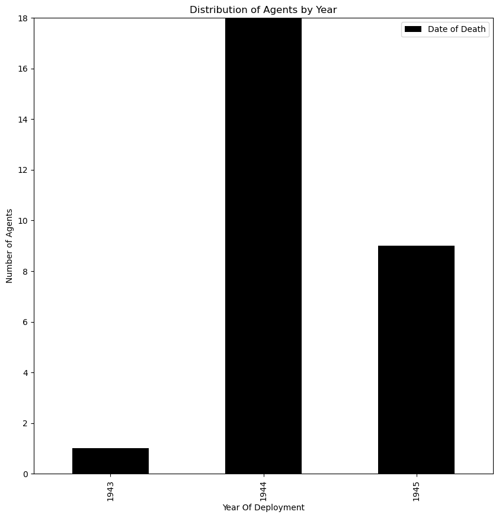

```python
print(counter41, " agents died in 1941, ", femcounter41, " were women, and ", (counter41-femcounter41), " were men.")

print(counter42, " agents died in 1942, ", femcounter42, " were women, and ", (counter42-femcounter42), " were men.")

print(counter43, " agents died in 1943, " , femcounter43, " were women, and ", (counter43-femcounter43), " were men.")

print(counter44, " agents died in 1944, ", femcounter44, " were women, and ", (counter44-femcounter44), " were men.")

print(counter45, " agents died in 1945, ", femcounter45, " were women, and ", (counter45-femcounter45), " were men.")


Died['Date of Death'].value_counts().sort_index().plot(kind='bar',figsize=(10,10),title='Distribution of Agents by Year', color='black', linewidth=3,legend=True,ylabel='Number of Agents',xlabel='Year Of Deployment', ylim=(0, 18))
```

Overwhelming, most agents included in this dataset died in 1944. This is because, as the war continued on, Nazi officers cracked down harder on rebellions in France as Allied war efforts picked up more, such as D-Day, and more people began to be killed in concentration camps, as the Nazi forces were struggling, and found power through execution. These final efforts for liquidation can be seen in the 9 agents killed in 1945 as the war drew to a close. The only exception to this, in 1943, was a naval death, as u-boat attacks were far more common far earlier in the war.

Another explanation for the spike in 1944 is that, the longer the war drew on, the longer agents were in the field, and the more susceptible they became for capture.

So, how long exactly did agents last in the field?

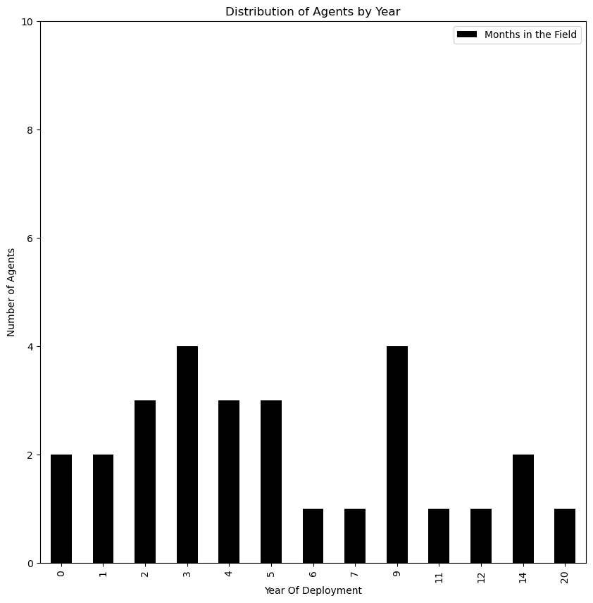

```python
Died['Months in the Field'].value_counts().sort_index().plot(kind='bar',figsize=(10,10),title='Distribution of Agents by Year', color='black', linewidth=3,legend=True,ylabel='Number of Agents',xlabel='Year Of Deployment', ylim=(0, 10))
```

As the above graph shows, agents in this dataset tended to be capture in the first 5 months of deployment. Then, there is a spike in the 9 month area. This shows the different potential reasons behind capture: either due to early failures in deployment, whether it be those agents who were captured immediately upon arrival (0 months), those who were not fit to be in the field for different reasons, or betrayal. After those first five months, an agent was more likely to survive with more experience under their belt. However, the longer they lasted in the field, the more chance for discovery, seen in the spike in 9 months.

So, now with an understanding of the general experiences of agents, how do these vary between genders?

# PER GENDER

Let's do a brief case study of two agents.

Yvonne Rudelatt and Henri Jacques Frager were deployed on the same day, on the same mission, Rudelatt as a Courier, Frager as an Organiser. They were also born in the same year, 1897, and were both 45 at the time of their deployment.

Rudelatt lasted only 11 months, while Frager lasted 20.

Why?

In working with gender, it can be easy to make assumptions about these diffences, that Frager lasted longer because he was a man while Rudelatt struggled because she was a woman. This is not what this dataset aims to prove, but instead to show how gender could have affected agents in different ways.

Rudelatt could have lasted less time because she was a courier, often on the move, which is gendered, as it was a role almost solely given to women who could roam freely, while Frager was an Organiser, an almost all-male role, that saw him more protected.

In reality, Rudelatt and a small group of other agents had the misfortune of arriving to a village full of Nazi troops, while a long string of betrayals saw Frager arrested by Nazi officers. **6**

This case study shows that, when analyzing gender, it can be easy to jump to conclusions or make assumptions. What this project hopes to do, instead, is to show the facts behind these agents deaths, and how gender might have affected them to get a larger picture, but by no means the whole one.

So, with all that being said, lets break down this information by gender.

```python
colors = ['#358f80', '#56ab91', '#78c6a3','#afe9c4']

Female = []
Female_Name = []
Female_Age = []
Female_Age_Range = []
Female_Location = []
Female_Death_Location = []
Female_Month_Deploy = []
Female_Cause_Death = []
Female_Country = []
Female_Job = []

Female_Age_Average = 0
Female_Year_Average = 0
Female_Month_Average = 0

x = 0

for index, row in Died.iterrows():


     if('Female' in row['Gender']):


        Female.append(row['Gender'])
        Female_Death_Location.append(row['Location of Death'])
        Female_Name.append(row['Name'])
        Female_Location.append(row['Location of Deployment'])
        Female_Month_Deploy.append(row['Months in the Field'])
        Female_Cause_Death.append(row['Cause of Death'])
        Female_Country.append(row['Country of Deployment'])
        Female_Job.append(row['Job'])

        Age_Calc=(row['Date of Death']-row['Date of Birth'])
        Female_Age.append(Age_Calc)


        Female_Year_Average=row['Date of Death'] + Female_Year_Average
        Female_Age_Average = Female_Age_Average + Age_Calc
        Female_Month_Average = row['Months in the Field'] + Female_Month_Average

        x+=1

        if(Age_Calc <= 29):
            Female_Age_Range.append("20s")
        elif(Age_Calc <= 39 and Age_Calc >= 30):
            Female_Age_Range.append("30s")
        else:
            Female_Age_Range.append("40s")

        Female_dataframe = pandas.DataFrame({'Name':Female_Name,'Gender': Female,'Age':Female_Age,'Age Range': Female_Age_Range,'Location of Deployment':Female_Location,'Location of Death':Female_Death_Location,'Country of Deployment':Female_Country,'Job':Female_Job,'Months in the Field':Female_Month_Deploy,'Cause of Death':Female_Cause_Death})

Female_dataframe
```

|  | Name | Gender | Age | Age Range | Location of Deployment | Location of Death | Country of Deployment | Job | Months in the Field | Cause of Death |
| --- | --- | --- | --- | --- | --- | --- | --- | --- | --- | --- |
| 0 | Andrée Borrel | Female | 25 | 20s | Bois Renard, 41210 Saint-Viâtre, France | Bas-Rhin, France | France | Courier | 9 | Concentration Camp Execution |
| 1 | Cecily Lefort | Female | 46 | 40s | Briollay, France | Ravensbrück, Germany | France | Courier | 3 | Concentration Camp Execution |
| 2 | Denise Bloch | Female | 29 | 20s | Armonville, 28310 Toury, France | Ravensbrück, Germany | France | Courier | 3 | Concentration Camp Execution |
| 3 | Diana Rowden | Female | 29 | 20s | Briollay, France | Bas-Rhin, France | France | Courier | 5 | Concentration Camp Execution |
| 4 | Eliane Sophie Plewman | Female | 27 | 20s | Lothiers, France | Dachau | France | Courier | 7 | Concentration Camp Execution |
| 5 | Haviva Reik | Female | 23 | 20s | Banská Bystrica, Slovakia | Kremnička, Slovakia | Slovakia | Field Agent | 2 | KIA |
| 6 | Lilian Rolfe | Female | 31 | 30s | Azay sur Cher, France | Ravensbrück, Germany | France | Wireless Operator | 3 | Concentration Camp Execution |
| 7 | Madeleine Barclay | Female | 32 | 30s | North Atlantic Ocean | Azores | North Atlantic Ocean | Wireless Operator | 3 | Drowned |
| 8 | Madeleine Damerment | Female | 27 | 20s | Sainville, France | Dachau | France | Courier | 0 | Concentration Camp Execution |
| 9 | Noor Inayat Khan | Female | 30 | 30s | Briollay, France | Dachau | France | Wireless Operator | 2 | Concentration Camp Execution |
| 10 | Vera Leigh | Female | 41 | 40s | Le Port, 37510 Villandry, France | Bas-Rhin, France | France | Courier | 5 | Concentration Camp Execution |
| 11 | Violette Szabo | Female | 24 | 20s | Azay sur Cher, France | Ravensbrück, Germany | France | Courier | 1 | Concentration Camp Execution |
| 12 | Yolande Beekman | Female | 33 | 30s | Villevêque\n49140 Rives-du-Loir-en-Anjou\nFrance | Dachau | France | Wireless Operator | 4 | Concentration Camp Execution |
| 13 | Yvonne Rudelatt | Female | 48 | 40s | Cap d'Antibes, France | Bergen-Belsen, Germany | France | Courier | 11 | Concentration Camp Succumbed to Sickness |

```python
Male = []
Male_Name = []
Male_Age = []
Male_Age_Range = []
Male_Location = []
Male_Death_Location = []
Male_Death_Location_Country = []
Male_Cause_Death = []
Male_Job = []
Male_Country = []
Male_Months = []

Male_Age_Average = 0
Male_Year_Average = 0
Male_Month_Average = 0

a = 0

location_holder = 0
Location_list = []

for index, row in Died.iterrows():

     if('Male' in row['Gender']):

        Male.append(row['Gender'])
        Male_Death_Location.append(row['Location of Death'])
        Male_Name.append(row['Name'])
        Male_Location.append(row['Location of Deployment'])
        Male_Cause_Death.append(row['Cause of Death'])
        Male_Country.append(row['Country of Deployment'])
        Male_Job.append(row['Job'])
        Male_Months.append(row['Months in the Field'])

        Male_Age_Calc=(row['Date of Death']-row['Date of Birth'])
        Male_Age.append(Male_Age_Calc)


        Male_Age_Average = Male_Age_Average + Male_Age_Calc
        Male_Year_Average = Male_Year_Average + row['Date of Death']
        Male_Month_Average = Male_Month_Average + row['Months in the Field']

        a+=1

        if(Male_Age_Calc <= 29):
            Male_Age_Range.append("20s")
        elif(Male_Age_Calc <= 39 and Male_Age_Calc >= 30):
            Male_Age_Range.append("30s")
        elif(Male_Age_Calc <= 49 and Male_Age_Calc >= 40):
            Male_Age_Range.append("40s")
        elif(Male_Age_Calc <= 59 and Male_Age_Calc >= 50):
            Male_Age_Range.append("50s")
        else:
            Male_Age_Range.append("60s")

for index, row in Died.iterrows():

     if('Male' in row['Gender']):

         if("," in row['Location of Death']):

            location_holder = row['Location of Death'][(row['Location of Death'].find(",")+2):]

            Location_list.append(location_holder)

         else:
            Location_list.append(row['Location of Death'])


Male_dataframe = pandas.DataFrame({'Name':Male_Name,'Gender': Male,'Age':Male_Age,'Age Range': Male_Age_Range,'Location of Deployment':Male_Location, 'Months in the Field': Male_Months, 'Location of Death':Male_Death_Location,'Country of Death':Location_list, 'Country of Deployment':Male_Country, 'Job':Male_Job, 'Cause of Death':Male_Cause_Death})
Male_dataframe
```

|  | Name | Gender | Age | Age Range | Location of Deployment | Months in the Field | Location of Death | Country of Death | Country of Deployment | Job | Cause of Death |
| --- | --- | --- | --- | --- | --- | --- | --- | --- | --- | --- | --- |
| 0 | Brian Dominic Rafferty | Male | 26 | 20s | Plauzat, France | 9 | Flossenbürg, Germany | Germany | France | Organiser | Concentration Camp Execution |
| 1 | Charles Skepper | Male | 39 | 30s | Briollay, France | 9 | Germany | Germany | France | Organiser | Unknown |
| 2 | John Dennis Barrett | Male | 28 | 20s | Seine & Marne, France | 4 | Buchenwald, Weimar, Germany | Weimar, Germany | France | Wireless Operator | Concentration Camp Execution |
| 3 | Ken McAlister | Male | 30 | 30s | Meusnes, France | 1 | Flossenbürg, Germany | Germany | France | Wireless Operator | Concentration Camp Execution |
| 4 | Eric Joseph Denis Cauchi | Male | 33 | 30s | Blye, France | 6 | Montbéliard, France | France | France | Weapons Instructor | KIA |
| 5 | Willem Frederik Hoogewerff, | Male | 24 | 20s | Berkel, Netherlands | 5 | 2244 AJ Wassenaar, Netherlands | Netherlands | Netherlands | Weapons Instructor | Executed |
| 6 | Stanislaw Makowski | Male | 30 | 30s | Nuret le Ferron, France | 4 | Romorantin-Lanthenay, France | France | France | Second in Command | Succumbed to Injury |
| 7 | Gustave Biéler | Male | 40 | 40s | Gondreville, France | 14 | Buchenwald, Weimar, Germany | Weimar, Germany | France | Organiser | Concentration Camp Execution |
| 8 | Julien Detal | Male | 29 | 20s | Daon, France | 0 | Buchenwald, Weimar, Germany | Weimar, Germany | France | Organiser | Concentration Camp Execution |
| 9 | Arthur Steele | Male | 23 | 20s | Souvigny, France | 9 | Buchenwald, Weimar, Germany | Weimar, Germany | France | Wireless Operator | Concentration Camp Execution |
| 10 | Hans Robert Filip Johansen | Male | 23 | 20s | Hvidsten, Denmark | 14 | Nyhavn, Copenhagen, Denmark | Copenhagen, Denmark | Denmark | Sabotage Instructor | KIA |
| 11 | Marcel Leccia | Male | 33 | 30s | Néret, France | 2 | Buchenwald, Weimar, Germany | Weimar, Germany | France | Organiser | Concentration Camp Execution |
| 12 | Robert Lefranc | Male | 23 | 20s | Villemade, France | 12 | Dracy Saint-Loup, France | France | France | Wireless Operator | KIA |
| 13 | Henri Jacques Frager | Male | 48 | 40s | Cap d'Antibes, France | 20 | Buchenwald, Weimar, Germany | Weimar, Germany | France | Organiser | Concentration Camp Execution |

## Average Age and Year of Death

So, how did gender affect the average age when agents died, the years they were deployed, and the time they spent in the field before dying?

```python
AverageAge = round(Female_Age_Average/x)
print("The Average Age of Death for Female SOE Agents:",AverageAge)

AverageYearofDeath = round(Female_Year_Average/x)
print("The Average Year Female SOE Agents Died:", AverageYearofDeath)

AverageTimeField = round(Female_Month_Average/x)
print("The Average time Female SOE Agents spent in the field before dying:", AverageTimeField)


print("    ")

MaleAverageAge = round(Male_Age_Average/a)
print("The Average Age of Death for Male SOE Agents:",MaleAverageAge)

AverageYearofDeathMale = round(Male_Year_Average/a)
print("The Average Year Male Agents Died:",AverageYearofDeathMale)


AverageTimeField = round(Male_Month_Average/x)
print("The Average time Male SOE Agents spent in the field before dying:", AverageTimeField)
```

```
The Average Age of Death for Female SOE Agents: 32
The Average Year Female SOE Agents Died: 1944
The Average time Female SOE Agents spent in the field before dying: 4

The Average Age of Death for Male SOE Agents: 31
The Average Year Male Agents Died: 1944
The Average time Male SOE Agents spent in the field before dying: 8
```

The easiest to answer is the shared year of death being 1944. 1943, as shown in the Deployment chart of all agents above, saw a spike in deployments. With more agents flooding into France, there was more chance for their capture and death, as seen in the spike of deaths in 1944, with more agents captured, and more killings occurred in concentration camps as the Nazi's feared the end of the war, and wanted to liquidate their camps.

However, to understand the time agents spent in the field, and their ages, there's some other factors we have to take into consideration.

To begin with explaining age, let's first explore the age break down by agents.

## Death by Age Range

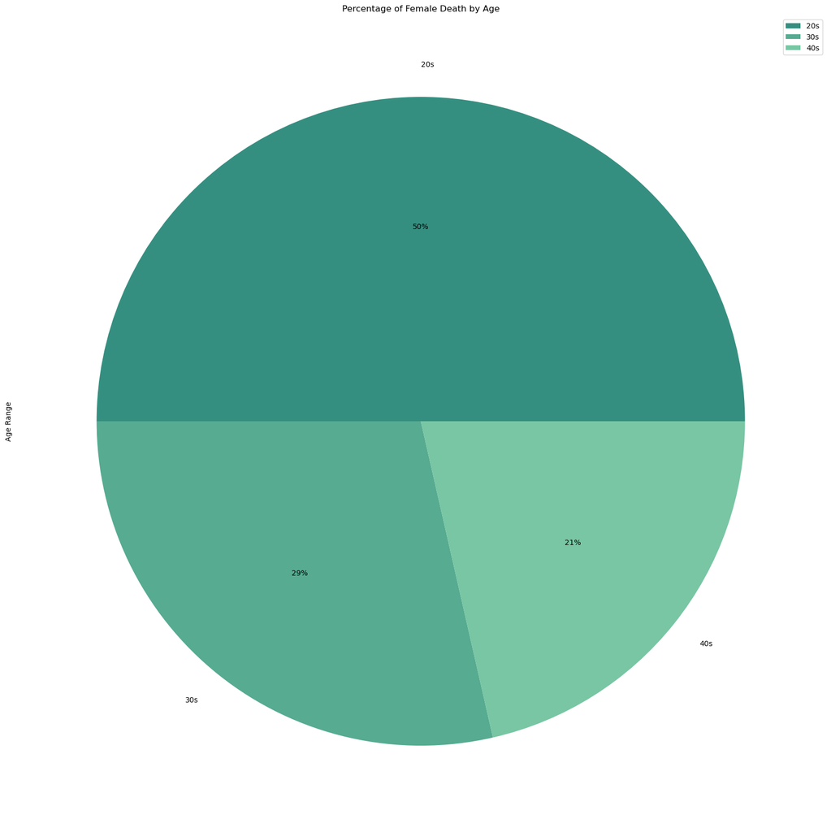

```python
Female_dataframe['Age Range'].value_counts().plot(kind='pie',figsize=(20,20),title='Percentage of Female Death by Age',legend=True,autopct='%1.0f%%',colors=colors)
```

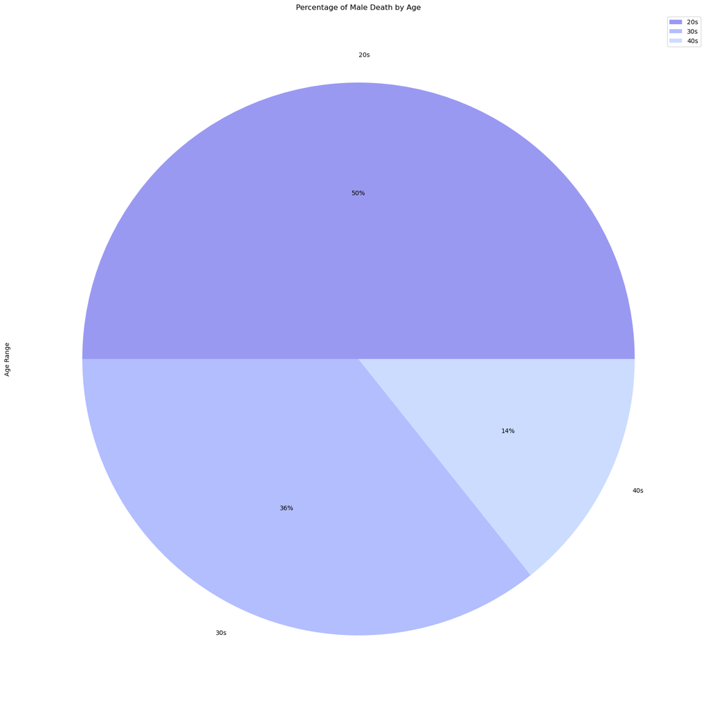

```python
Mcolors = ['#9a99f2','#b3beff','#ccdcff','#e6f2ff','#fbfaff']

Male_dataframe['Age Range'].value_counts().plot(kind='pie',figsize=(20,20),title='Percentage of Male Death by Age',legend=True,autopct='%1.0f%%',colors=Mcolors)
```

As we can see, despite the average age of female agents being 32 and male agents 31, in reality, half of agents included in this dataset died in their 20s, followed closely by their 30s, with men actually 7% more likely to die in their 30s and women 7% more likely to die in their 40s.

These close percentages show less than gender's affects on age, but the age distribution of agents, who needed to be young enough to have the physical stamina and energy for espionage, but mature enough to survive in the field. For women specifically, they had to hit a sweet spot where they were not too young, but not too old to have started a family (though agents such as Violette Szabo did already have children). This is not to say that agents had to be young, as many were deployed in older ages, as seen in the "Life" Section of this website, but for the agents who died, we can see that half were quite young.

These younger agents were also on the move more, as most female agents in their 20s were couriers and on the go, while agents in their 30s were typically wireless operators, who were more stationary. Male agents, comparatively, had far more diverse jobs based on ages.

So, we can see that jobs might have had an impact on agent's deaths, so what were the actual job breakdowns based on gender?

# DEATH BY JOB

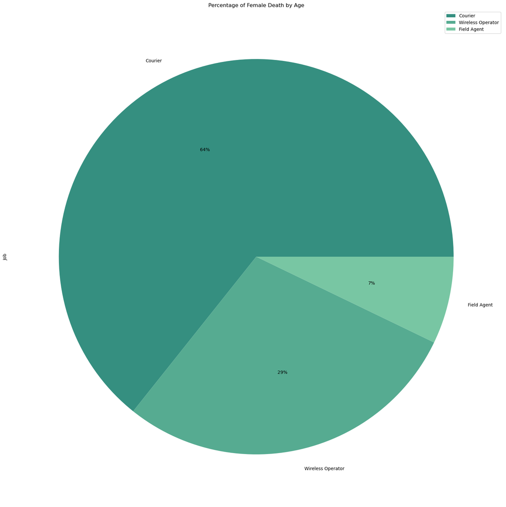

```python
Female_dataframe['Job'].value_counts().plot(kind='pie',figsize=(20,20),title='Percentage of Female Death by Age',legend=True,autopct='%1.0f%%',colors=colors)
```

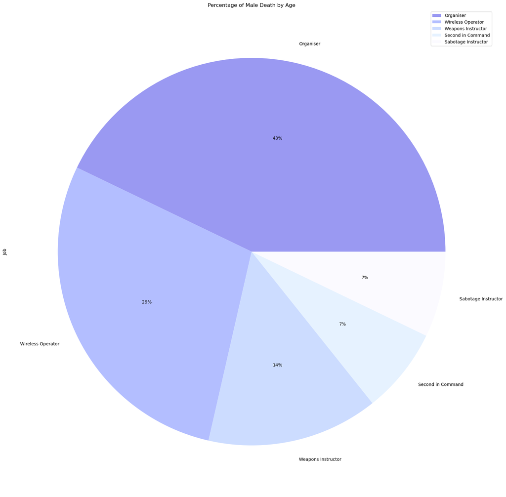

```python
Mcolors = ['#9a99f2','#b3beff','#ccdcff','#e6f2ff','#fbfaff']

Male_dataframe['Job'].value_counts().plot(kind='pie',figsize=(20,20),title='Percentage of Male Death by Age',legend=True,autopct='%1.0f%%',colors=Mcolors)
```

Perhaps the most telling effect of gender on agents deaths is in the roles they were given. Women were given more clerical and 'safe' jobs, or jobs that benefitted from their gender. These roles are most often wireless operators, considering they have typist experience and this role often kept women inside and away from imminent danger in the field, or being couriers, in which their gender allowed them to travel far more freely around France compared to male agents, as men were either off being labour or imprisoned, leaving only the unfit and the elderly in France.

However, as we can tell between these two graphs, being a courier was a highly dangerous job. Being constantly on the move, and carrying potentially incriminating evidence, was extremely dangerous, and these women were far more likely to be stopped. Cecily Lefort, when questioned by the Gestapo, could not answer all of their questions, and as such was sent to Ravensbruck, where she was killed.**7** Wireless operators were also in danger if they transmitted for too long, or in the same spot for too many days, as this could be tracked. Being staionary itself was in general an issue, such as for Lilian Rolfe, who was captured from the room she was transmitting, despite the fact the Gestapo were looking for someone else entirely.**8**

Couriers were 21% more likely to die than organisers, the most killed male categoy. This was another gendered job, as Organisers, who were in charge of circuits, were almost only male, with two exceptions: Virginia Hall and Pearl Witherington Cornioley, both who survived the war.

The only exception for women to being a courier and wireless operator was Haviva Reik, who was parachuted into her home country of Slovakia to aid the Jewish population from Nazi prosecution. **9**As she was Jewish herself, when her group was discovered, she was shot outright, the only woman to be a field agent and killed in action, based not on gender but on religion.**10**

Male agents had more variety, as those featured in this dataset were also weapons and sabotage instructors and Second in Command when they died. These were also dangerous jobs, as they were the ones directly in charge of deadly weapons and explosives, as well as they were the ones in the field organizing sabotage, meaning if they were caught, they could be killed outright in the battle that pursued. This was the case for Eric Cauchi, who was shot during a brawl that broke out between the Maquis and Gestapo.**11**

So, to return to the above average that women only lasted 4 months in the field, while men lasted 8. Female agents jobs in the field saw them far more likely to be captured out in the field as couriers or through being wireless operators. Male agents, however, were not couriers, providing them another level of safety, and more time in the field, but their dangerous jobs also saw them eventually captured or killed.

The time agents spent in the field, however, is far more varied that the 4 and 8 month statistic allows. Lets explore the months each gender spent in the field.

## Months in the Field by Gender

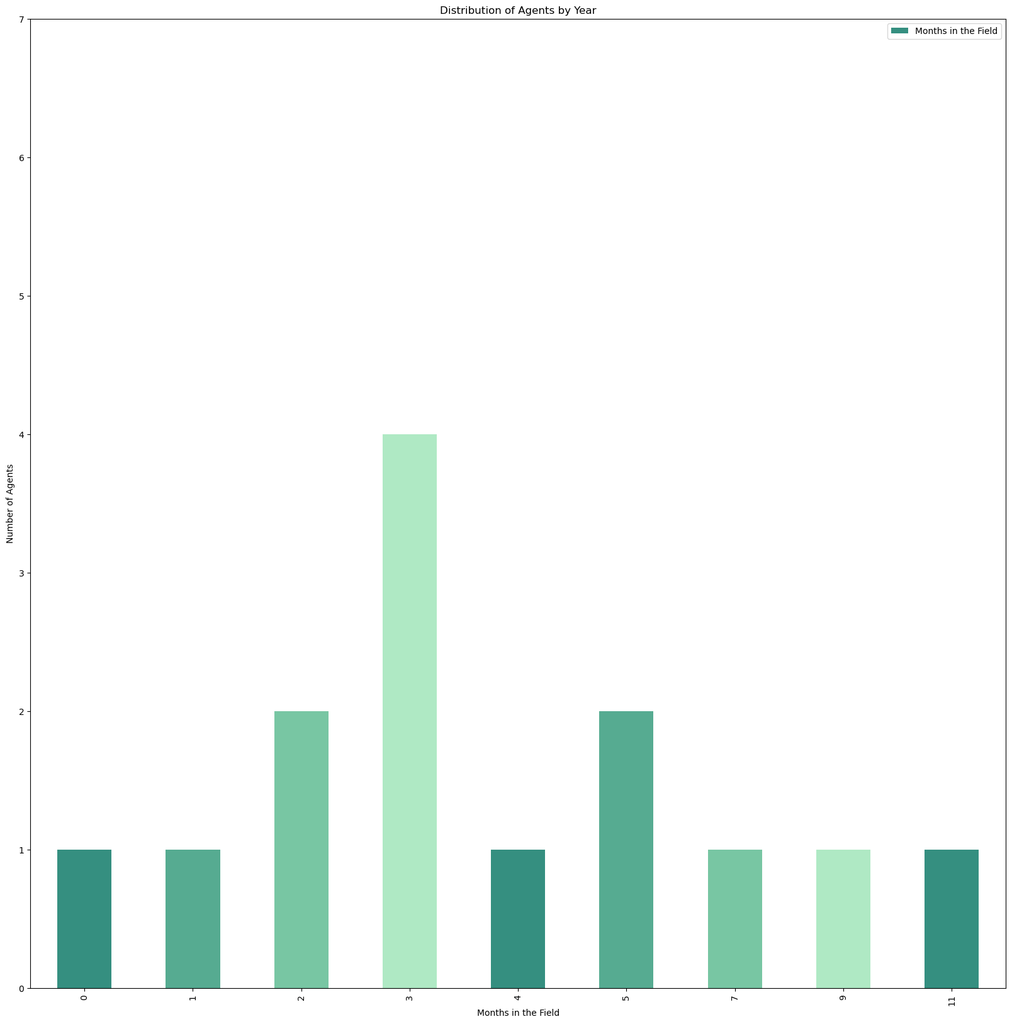

```python
Female_dataframe['Months in the Field'].value_counts().sort_index().plot(kind='bar',figsize=(20,20),title='Distribution of Agents by Year', color=colors, linewidth=3,legend=True,ylabel='Number of Agents',xlabel='Months in the Field', ylim=(0, 7))
```

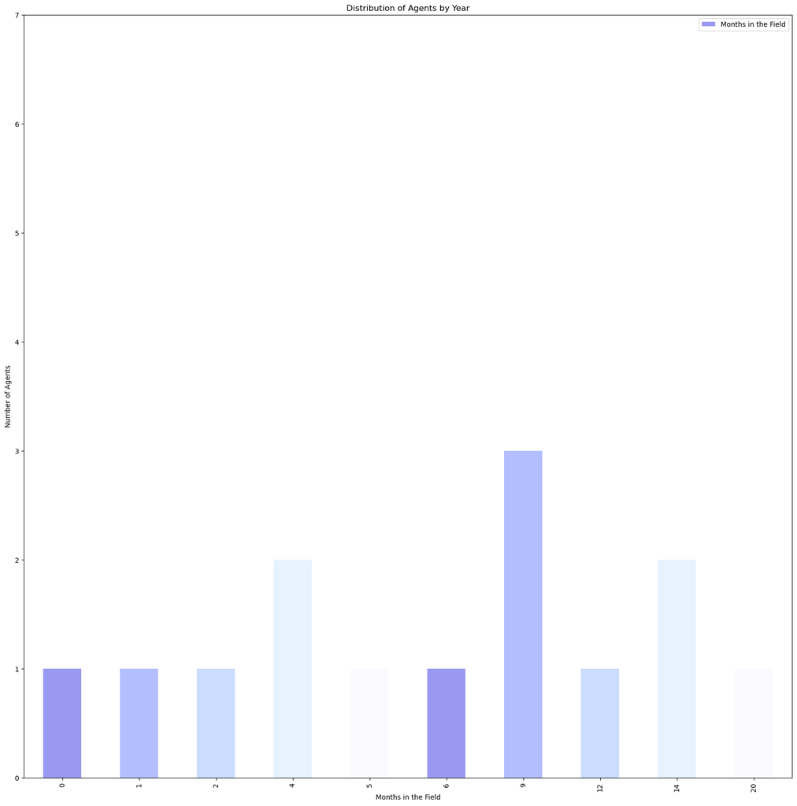

```python
Male_dataframe['Months in the Field'].value_counts().sort_index().plot(kind='bar',figsize=(20,20),title='Distribution of Agents by Year', color=Mcolors, linewidth=3,legend=True,ylabel='Number of Agents',xlabel='Months in the Field', ylim=(0, 7))
```

As we can see, most agents spent different time in the field, with certain months containing clusters for each gender. For female agents, the largest clusted is at the 3 month period, whereas for male agents, its at the 9 month period, which explains the averages of 4 and 8 months respectively. Outside of these, however, we can see that agents spent varied times in the field based on different circumstances. An example of this is that Madeline Damerment and Julien Detal were both captured upon deployment, as the betrayal of their circuits allowed Nazi officers to find out where they would be dropped, and meet them there. **12**

The longest time a female agent spent in the field, who died, was Yvonne Ruddelatt at 11 months, while for a male agent who died, it was Henri Frager at 20. As we are using a limited dataset, it can be imagined there would be more variety for male agents, but this small sample still can help us see how gender impacted time in the field, with men routinely lasting longer, and women lasting less. This can both be seen as a gendered issue, with female agents given different jobs that saw them captured more, but it is also circumstantial. Why Yvonne Ruddelat lasted 11 months in the field, compared to Ken McAlister lasting 1, might be gender, or it might be due to different circumstances of where and when they were placed and their own work. If given the chance, with more time and more resources, one could explore more deeply the reasons behind agents capture and death, but for now, we can see how gender's impact on jobs, and in turn, the time agents spent in the field and the likihood of their deaths.

## LOCATION OF DEPLOYMENT

How did gender impact location of deployment?

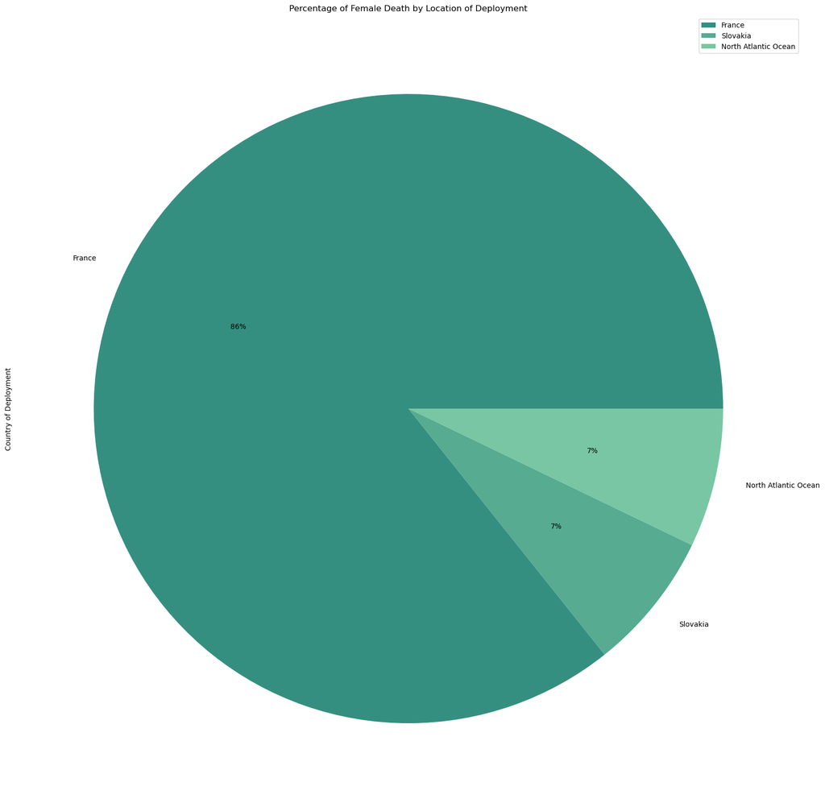

```python
Female_dataframe['Country of Deployment'].value_counts().plot(kind='pie',figsize=(20,20),title='Percentage of Female Death by Location of Deployment',legend=True,autopct='%1.0f%%',colors=colors)
```

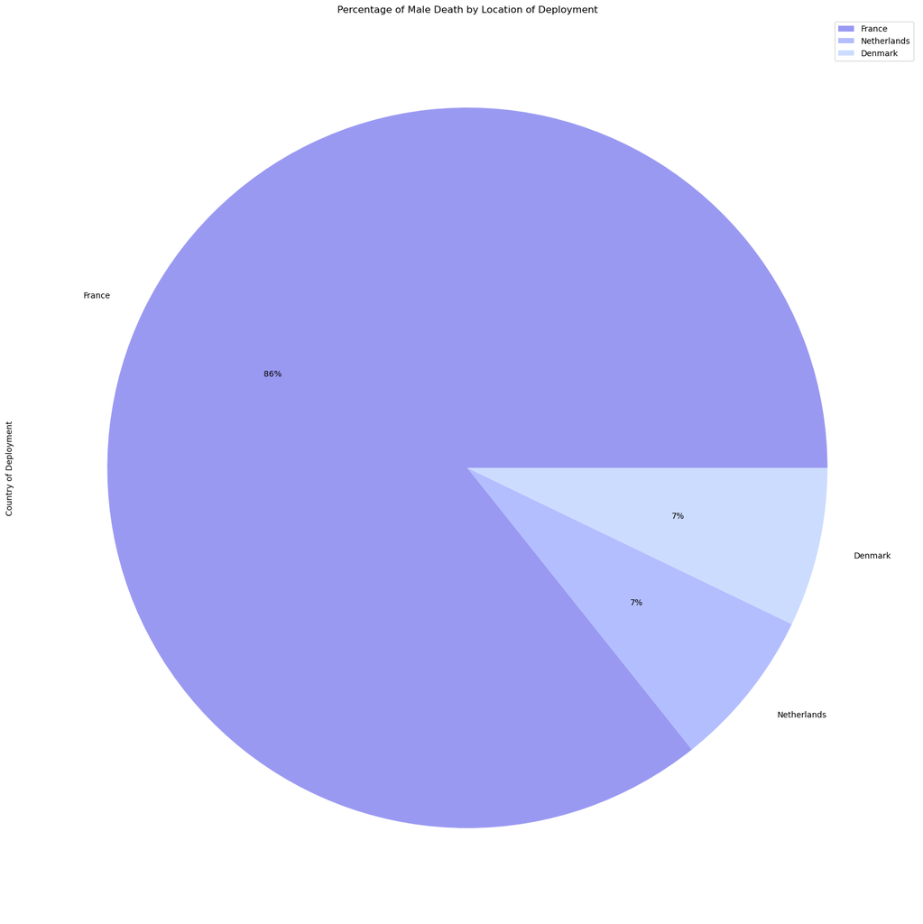

```python
Male_dataframe['Country of Deployment'].value_counts().plot(kind='pie',figsize=(20,20),title='Percentage of Male Death by Location of Deployment',legend=True,autopct='%1.0f%%',colors=Mcolors)
```

This, one again, is a bias of the agents chosen for this dataset. Female agents were fairly strictly deployed in France, as it was the main area the S.O.E. concentrated their efforts, many women had education in French and could pass within the country, and in general, it was seen as safer than other areas of deployment. As such, when matching agents to the female agents deployed in France, they will also be deployed in France, despite the many countries male S.O.E. agents were deployed in.

The two outliers, Slovakia and the North Atlantic Ocean are circumstantial, with Haviva Reik parachuted into Slovakia, as it was her home country, and Madeline Barclay placed with her partner on a submarine. For the male agents, as it was difficult to track agents deployed around the same time, I chose two male agents who were deployed in different countries, but still in close time frames to the two outlying female agents.

While location of deployment might not reveal much, what about their location of death?

## Percentage of Female Death by Location of Death

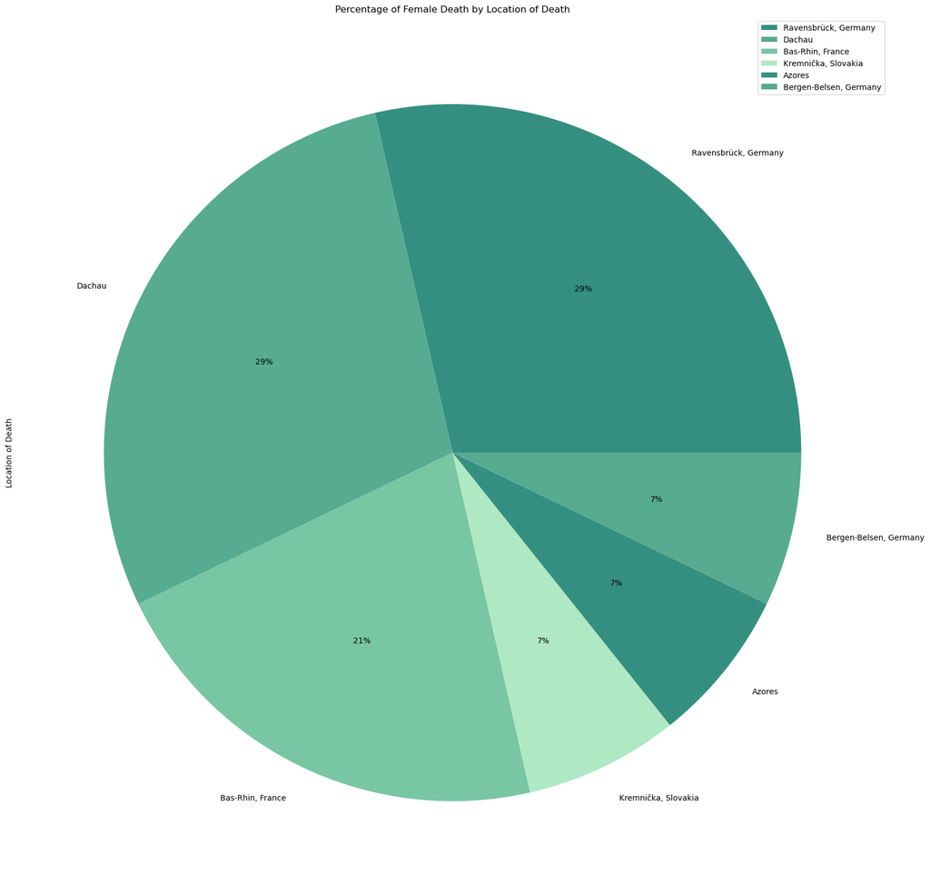

```python
Female_dataframe['Location of Death'].value_counts().plot(kind='pie',figsize=(20,20),title='Percentage of Female Death by Location of Death',legend=True,autopct='%1.0f%%',colors=colors)
```

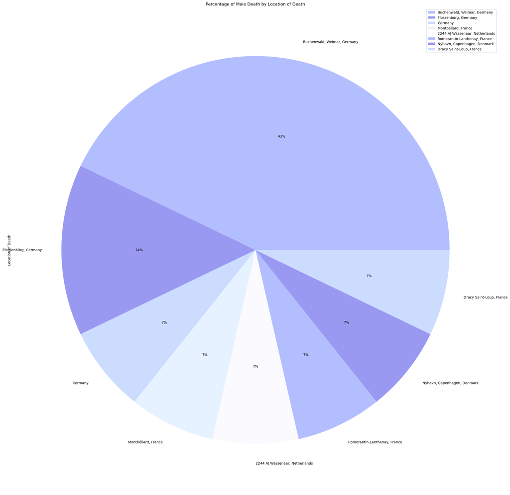

```python
Mcolors = ['#b3beff','#9a99f2','#ccdcff','#e6f2ff','#fbfaff']

Male_dataframe['Location of Death'].value_counts().plot(kind='pie',figsize=(25,25),title='Percentage of Male Death by Location of Death',legend=True,autopct='%1.0f%%',colors=Mcolors)
```

Gender can very clearly be seen in the places agents died.

To begin, no female and male agents shared a death location within this dataset. This comes down to a few factors.

First: Concentration camps.

Men and women were sent to different concentration camps due to how the Nazi regime organized them. Ravensbruck, where 29% of female agents died, was a solely female concentration camp. The 29% of women sent to Dachau is another oddity, as it was in fact a men's camp, however the women were transferred there to be immediately killed.**13** Buchenwald, conversely, where 43% of men died, had only one female barrack, and at one point held over 40 male Allied agents.**14** Flossenburg, making up 14% of deaths was a labour camp where men were used to work in factories. Bas-Rhin, which was the Natzweiler-Struthof camp during the Second World War, was for mainly members of the resistance, in which 21% of female agents died. Interestingly, no male agents included in this dataset died in Natzweiler, likely because Natzweiler was also a transit camp, sending them to other camps, where they would have been worked to death and killed.**15** Yvonne Ruddelat, the only female agent to be killed in Bergen-Belsen, had been moved there were a large group of other women who were sick, as the camp was already overrun with sickness.**16**

There were a couple motives for moving agents to concentration camps. In general, concentration camps were used for labour. As M.R.D. Foot outlines, concentration camps "had a considerable role to play in the nazi economy", meaning for able bodied agents, they were worked until it was decided they should be killed.**17** For women specifically, it allowed them to be discreetly killed far away from where they were deployed.

Secondly: Killed in Action and Succumbing to Injuries

Save for Haviva Reik, these forms of death were solely masculine, and in turn, changed where men died. For example, Stanislaw Makowski, who was the only agent of this dataset to die in Romorantin-Lanthaney, succumbed to his injuries in a hospital there after he was shot in the field.**18**. Eric Cauchi, the only agent to die in Montbeliard, and Robert Lefranc, the only agent to die in Dracy Saint-Loup, were both killed in action. Here, gender plays a direct part in where male agents died, as their jobs, such as Cauchi being a weapons instructor, were solely masculine, and in turn led to solely masculine deaths of being killed or injured in the field, rather than captured and sent away.

As such, as we can see that gender affected where agents died, but how about their causes of death?

# CAUSE OF DEATH

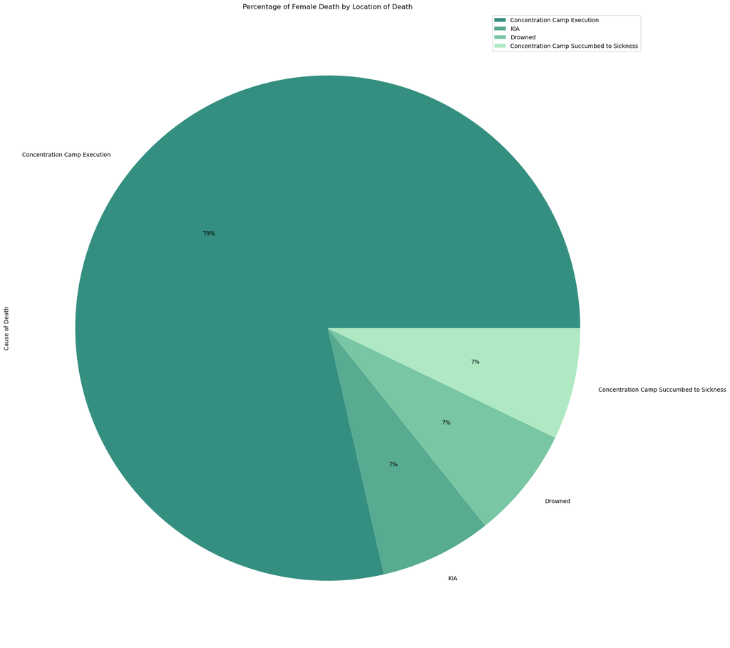

```python
Female_dataframe['Cause of Death'].value_counts().plot(kind='pie',figsize=(20,20),title='Percentage of Female Death by Location of Death',legend=True,autopct='%1.0f%%',colors=colors)
```

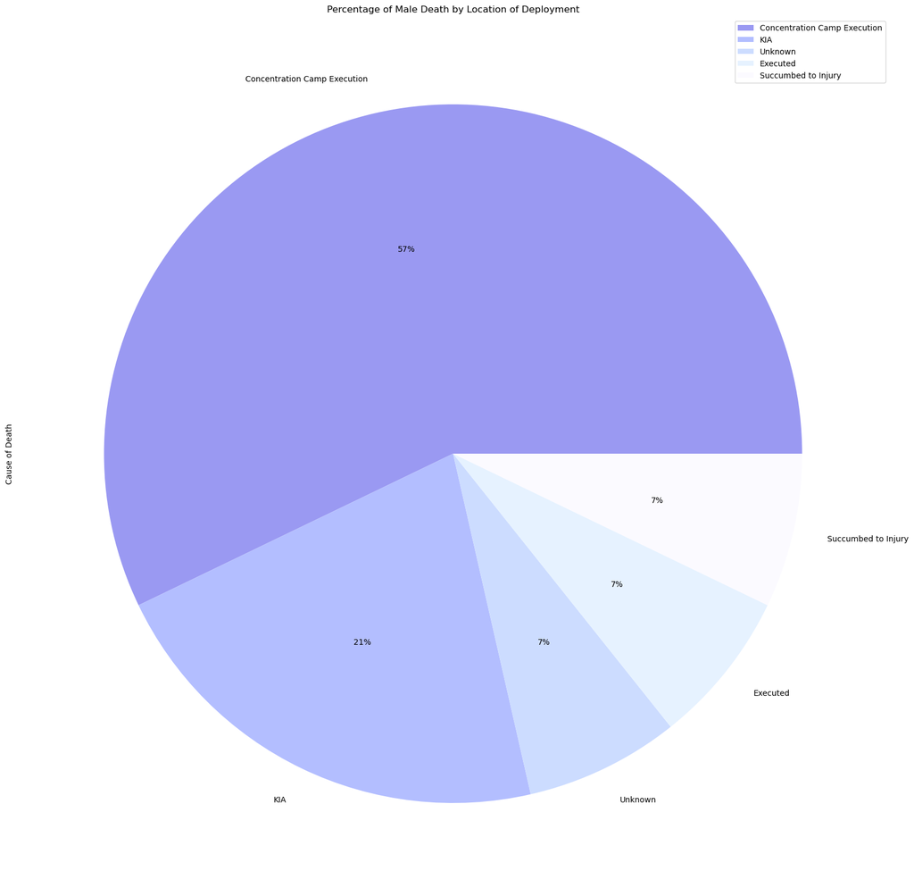

```python
Male_dataframe['Cause of Death'].value_counts().plot(kind='pie',figsize=(20,20),title='Percentage of Male Death by Location of Deployment',legend=True,autopct='%1.0f%%',colors=Mcolors)
```

The cause of death for most agents is Concentration Camp Executions (and in the case of Yvonne Ruddelat, succumbing to illness in a Concentration Camp), as in the case for women, it was a 'taboo' to kill women outright, though they would then go on to suffer far worse deaths in concentration camps.

These female agents deaths also varied within the camp. Beekman, Szabo, Bloch, Rolfe, Khan, Damerment and Plewman were shot, and Borrel, Leigh and Rowden were given lethal injections and then burned, Ruddelat died from sickness due to the poor conditions in the camps, and Lefort was gassed. These varieties come from the Nazi urgency for them to die, specifically those who were confirmed to be agents: Borrel, Leigh, Rowden, Khan, Damerment, Plewman and Beekman, while others, Szabo, BLoch, Rolfe, Ruddelat, and Lefort suffered through the camp system.**19**

For male agents, if they were resistance members who were caught, they were not treated as soldiers, and many tried to hold onto their secret identities, meaning they would be treated as rebels and enemies to the Nazi regime, and as such, could be sent to concentration camps, rather then POW camps.

These agents deaths varied within the camps. Bieler was shot, however, the majority were hanged, with some disputes of the form of hanging. M.R.D. Foot records that agents were hung using piano wire, to draw out suffering as long as possible, while Pearl Withinerinton Cornioley records that agents were physically hung off of meat hooks, through the base of the skull. **20** Either way, we can see that even in concentration camp deaths, women were typically killed as fast and, in a dark way of thinking, humane way as possible, while the men suffered.

It was far more rare for female agents to be Killed in action, with male agents three times as likely to be killed in action. Killed in Action, and Execution, are both more masculine deaths, once again because men were more likely to be caught in the crossfire, and women were far more likely to be captured and then sent to camps.

It was also more likely for male agents outside of France to be killed outright. While it is only two agents, both suffered more unique deaths. Hans Johansen, when cornered in the shootout, chose to use a cyanide pill given to agents, rather than go through the torture and interrogation that might have followed. Willem Indische Hoogeworf's death is one that carries a bit more emotion.

When captured, he was sent to Oranjehotel, a prison in the Hague, where he was in relatively good spirits, the prisoners were treated well, and in a letter he managed to get smuggled out to his fiance, that he believed he would be released.**21** However, a high ranking Nazi officer was injured in a random ambush, and in retaliation, he had the prison liquidated, and all killed.**22** Hoogeworf was identified in the pile of bodies by his fiace based on his underwear.**23** He left one, final message for her carved in his prison cell wall: *My darling is Marietje B., to whom I remain eternally faithful, whom I sincerely love.***24**

# Conclusion

So, what have learned about the gendered causes behind S.O.E. Agents deaths?

In total, there were many aspects in which death was gendered. From the onset, men and women's jobs were gendered, beginning with deployment. In total, 14 women were deployed who died, whereas many more male agents died, however due to the nature of this dataset, 14 male agents were chosen for examination to make the 14 female agents. Their jobs, and in turn deaths, were inherently gendered, with no female agents who died given a position of power, whereas 50% of male agents who died were. Instead, 64% of female agents who died were couriers, a job none of the male agents had, with couriering a dangerous job that saw women under heavy suspicion. As Phylis Latour, an agent who survived her time in the field explained, "as women there were even fewer protections for us if we were caught and survived the initial threat of execution. Many of the male SOE agents were treated much better by the German authorities than we were, because, allegedly, women were not covered by the Geneva Convention at the time. Our SOE women who died, died horrible deaths after enduring indescribable torture."**25** Equal amount of men and women were wireless operators, showing the dangers of a wireless set being detected.

Female and male agents cause of death, and where they died, also was heavily affected by gender, with men three times as likely to die in the field, whereas women were 29% more likely to die in a concentration camp. Men, given roles that saw them engaging in riskier behaviour and battles meant that they could be killed outright in the field, whereas women were to be captured, then sent away to concentration camps to immediately be killed or put to work secretly. Heinrich Himmler, when speaking of the treatment of spies, was recorded to have said "The agents should die, certainly, but not before torture, indignity and interrogation had drained from them that last shred and scintilla of evidence which should lead to the arrest of others. Then, and only then, should the blessed release of death be granted to them".**26** This was true for both men and women who endured brutal torture, but their deaths varied after torture, with women given quicker deaths, such as being shot or given lethal injection, while men were hanged to draw out their suffering. Despite this, these men and women did not go easily, and not without their own forms of retaliation. Elaine Plewman, Noor Inyat Khan, Madeline Damerment, and Yolande Beekman all held hands while they were shot.**27** Odette Sansom, who survived her time at Ravensbruck, put curlers made of stocking in her hair every night "religiously in case they would fetch me the next morning to put me to death. I wasn’t going to be seen going to my death without my curls."**28** Similarly, Brian Stonhouse as recounts of witnessing Andree Borrel, Vera Leigh and Diana Rowden marching to their deaths, "One of the most touching features, they hadn’t makeup on, but you could that they had been in jail for several months, and one of the girls had a ribbon in her hair as a defiant gesture. It was very touching."**29** Of the male agents, "many sung the Marseillaise on their way to the scaffold , and cried ‘ vive l'Angleterre, vive la France' as their last words."**30**. Death might have ended these agents, but not what they stood for.

Agents who survived had high regard for those who put their lives on the line. Phylis Latour, who wrote a book about her experiences during the war, would only do so if the female agents who died were acknowledged.**31** "The treatment these women endured before they died was horrific," She explained, "I could say so much more, but it would be disturbing. Please read about it, read about them all."**32** John Goldsmith, a weapons instructor who survived the war, was proud that none of the men he trained were killed, but "The casualty lists that had accumulated on the way were already too long. They were filled...S.O.E. agents who had prayed during the years of stealth, sabotage and subversion that one day they would be able to put on uniform and face their enemy in the open. Instead, many of them ended their lives in rags in the execution yards of Himmler’s unspeakable prisons."**33** Vera Atkins, one of the directors of the F Section, travelled across Europe to track down the fate of as many agents as possible, and the agents themselves aided how they could. Brian Stonehouse, who witnessed the female agents given lethal injections, was tracked down by Diana Rowden's mother, desperate to know the fate of her daughter. "I got this letter from one of the girls mother, sending me a photograph of this girl, saying “was this one of the four?” and I was...85% sure it was...but...would a parent want to know something like that?"**34** Asking his own parents, they told him "it’s better to know the worst then to go on hoping and never know," so he wrote back to Rowden's mother to say he believed he saw her, the first confirmation to the Rowden's that their daughter had been killed.**35**

There is not a single S.O.E. agent untouched by gender, or by death. They were well aware, when they were trained, that it was unlikely they would return. "We all knew that the remaining life expectancy of a male wireless operator who entered occupied France was just six weeks," Explained Latour of the dangers in the field, "And on more than one occasion had it explained to us that the chances of us coming back were 50/50."**36** All agents were issued cyanide pills, allowing them a quick and painless death, and yet some, like Latour, refused them. She decided she would rather focus on her survival.**37** For Odette Sansom, survival came one minute at a time as she was tortured, for if she could survive one more minute, surely she could survive the next.**38**

Gender affected the deaths of S.O.E. agents in countless ways, from dictating what jobs they had and their liklihood for survival, how long they lasted in the field, where they were killed, and how. Through digital methods and quantitative analysis, I hope this work shows you the finer details of the intricacies for those involved in my dataset, but once again, that this dataset is just the beginning. It covers 28 agents, whereas countless more died.

Understanding the Gendered S.O.E. experience serves as a way to honour these brave souls and their sacrifices, and to better understand how their indentities shaped their deaths.

# Endnotes

1.Johansen 2.Barclay 3.Reik

4.M. R. D. Foot, *SOE in France: An Account of the Work of the British Special Operations Executive in France 1940-1944*, (Oxford: Taylor and Francis, 2004): 44, https://doi.org/10.4324/9780203496138; Kate Vigurs, *Mission France:The True History of the Women of SOE.* (Yale University Press, 2021): 167.

5.Stonehouse, newspaper 6.Rudellat and Frager 7.Lefort 8.Rolfe 9.Reik 10.Reik 11.Cauchi 12.Damerment and Detal 13.Vigurs 14.Buchenwald 15.Natsweiler 16.Rudellat 17.Foot 18.Stanislaw 19.Pattinson 20.Foot and Pearl 21.Video 22.Video 23.Video 24.Video 25.Latour 26.Vigurs 27.Vigurs 28.SANSOM - passing 29.STONEHOUSE 30.Foot, *SOE in France*, 425. 31.LATOUR 32.LATOUR

33.John Goldsmith, *Accidental Agent* (Yorkshire: Pen and Sword Military, 2016): 18 (PDF).

34.STONEHOUSE 35.STONEHOUSE 36.LATOUR 37.LATOUR

38.ThamesTV, "Odette Hallowes interview | World war Two | intelligence officer | Afternoon plus | 1980", September 15, 2018: 00:04:25-00:04:25. https://www.youtube.com/watch?v=N7oN6xSnG4Y.

## Bibliography

Foot, M. R. D. SOE in France: An Account of the Work of the British Special Operations Executive in France 1940-

```
1944. Oxford: Taylor and Francis, 2004. https://doi.org/10.4324/9780203496138.
```

Latour, Pippa. The Last Secret Agent: The Extraordinary Story of a WW2 Spy, Told in Her Own Words. Monoray, 2024.

Pattinson, Juliette. Behind Enemy Lines: Gender, Passing and the Special Operations Executive in the Second World War. Manchester: Manchester University Press, 2007.

Vigurs, Kate. *Mission France:The True History of the Women of SOE.* Yale University Press, 2021.

Wilkinson, Laurence. "The Fiend Woman of Buchenwald", *The Sunday Express* (London, UK), April 22, 1945.

Witherington Cornioley, Pearl. Codename Pauline. Chicago: Chicago Review Press, 2013.